# Climate Connect: Assignment

### This Assignment is given as a recruitment process task for Machine Learning Post in Climate Connect

#### The task is to predict power, given two datasets.

##### Datasets:

1. power_actuals.csv: the datasets contains: Shape: (70080, 4)
2. weather_forecast and weather_actuals: Shapes: (14267, 31)

**Attributes are self-explanatory**

```python
# import all the neccessary library
import numpy as np # linear algebra
import pandas as pd # data processing, CSV file I/O (e.g. pd.read_csv)

import matplotlib.pyplot as plt
import seaborn as sns

import warnings
def ignore_warn(*args, **kwargs):
    pass
warnings.warn = ignore_warn #ignore annoying warning (from sklearn and seaborn)

# machine learning
from sklearn.linear_model import ElasticNet, Lasso,  BayesianRidge, LassoLarsIC
from sklearn.ensemble import RandomForestRegressor,  GradientBoostingRegressor
from sklearn.kernel_ridge import KernelRidge
from sklearn.pipeline import make_pipeline
from sklearn.preprocessing import RobustScaler
from sklearn.base import BaseEstimator, TransformerMixin, RegressorMixin, clone
from sklearn.model_selection import KFold, cross_val_score, train_test_split
from sklearn.metrics import mean_squared_error
import xgboost as xgb
import lightgbm as lgb

from sklearn.model_selection import cross_val_score
from sklearn.tree import DecisionTreeClassifier
from sklearn.linear_model import LinearRegression, RidgeCV, LassoCV, ElasticNetCV

from sklearn.model_selection import cross_val_score, train_test_split
from sklearn.preprocessing import StandardScaler
from sklearn.linear_model import LinearRegression, RidgeCV, LassoCV, ElasticNetCV
from sklearn.metrics import mean_squared_error, make_scorer
from scipy.stats import skew
from sklearn import metrics
from scipy.stats import norm
from scipy import stats

pd.set_option('display.max_columns', None)
sns.set_style('whitegrid')
%matplotlib inline
```

```python
power_actual = pd.read_csv("./power_actual.csv")
power_actual = power_actual.rename(columns={'datetime': 'datetime_local'})
power_actual = power_actual.drop(columns=["Unnamed: 0"])
power_actual.drop_duplicates()

print(power_actual.shape)
power_actual.head()
```

```
(70080, 4)
```

|  | datetime_local | ghi | gti | power |
| --- | --- | --- | --- | --- |
| 0 | 2017-10-01 00:00:00 | 0.0 | 0.0 | 0.0 |
| 1 | 2017-10-01 00:15:00 | 0.0 | 0.0 | 0.0 |
| 2 | 2017-10-01 00:30:00 | 0.0 | 0.0 | 0.0 |
| 3 | 2017-10-01 00:45:00 | 0.0 | 0.0 | 0.0 |
| 4 | 2017-10-01 01:00:00 | 0.0 | 0.0 | 0.0 |

```python
power_actual.describe()
```

|  | ghi | gti | power |
| --- | --- | --- | --- |
| count | 35040.0 | 35040.0 | 70080.000000 |
| mean | 0.0 | 0.0 | 28.612915 |
| std | 0.0 | 0.0 | 498.795887 |
| min | 0.0 | 0.0 | 0.000000 |
| 25% | 0.0 | 0.0 | 0.000000 |
| 50% | 0.0 | 0.0 | 0.000000 |
| 75% | 0.0 | 0.0 | 5.540000 |
| max | 0.0 | 0.0 | 16172.040000 |

#### Observations:

1. Clearly, ghi and gti columns has same values (=0), imparting no features to Model. We should drop it.
2. Power feature is only main target features we need, here.

```python
power_actual.drop(columns=["ghi","gti"],inplace=True)
power_actual.head()
```

|  | datetime_local | power |
| --- | --- | --- |
| 0 | 2017-10-01 00:00:00 | 0.0 |
| 1 | 2017-10-01 00:15:00 | 0.0 |
| 2 | 2017-10-01 00:30:00 | 0.0 |
| 3 | 2017-10-01 00:45:00 | 0.0 |
| 4 | 2017-10-01 01:00:00 | 0.0 |

Before we merge with other datasets, let's check Normality of Power Dependent Variable .i.e the Power data should look like a normal distribution.

```
Skewness of Power Attributes 22.720964876396202
```

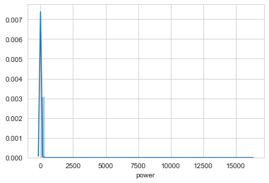

```python
sns.distplot(power_actual['power']);
print("Skewness of Power Attributes {}".format(power_actual["power"].skew()))

# Skewness is pretty high and seeing the histogram, we can do things here: slicing or transformation.
# Slicing seems more promising here.
```

```python
# slicing:
# Here we see # of samples of power == 0 is 42082. Clearly this (42082/70080)*100= 60.04 %,
# it is not good if we are solving regression problem.
tt = power_actual["power"].value_counts().sort_index()
print(tt.head(10))
print("**"*5)

# tail here show how power feature distribution here.There are only just 257 samples having > 20 power.
# there are 466 rows that has only 1 counts
# 27721 is the no of samples that has values between and 0.001 - 20,
# rest can be treated as outliers(clear from above histogram )
print(tt[tt==1])
```

```
0.000000    42082
0.010000       73
0.010769        1
0.013077        1
0.020000       76
0.026667        1
0.030000       41
0.040000       75
0.050000       26
0.060000       68
Name: power, dtype: int64
**********
0.010769        1
0.013077        1
0.026667        1
0.139231        1
0.147500        1
               ..
15127.800000    1
15504.750000    1
15554.660000    1
15952.180000    1
16172.040000    1
Name: power, Length: 466, dtype: int64
```

```
Skewness of Power Attributes -0.023836465758554214
```

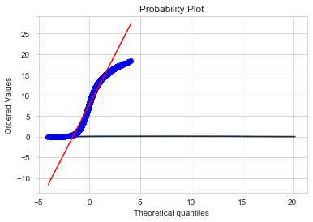

```python
power_actual = power_actual[(power_actual["power"] > 0.001) & (power_actual["power"]<20)]

# plot
sns.distplot(power_actual['power'], fit=norm);
res = stats.probplot(power_actual['power'], plot=plt)
print("Skewness of Power Attributes {}".format(power_actual["power"].skew()))

# Skewness Difference drop from 22.72 ---> -0.02. This is much better.
```

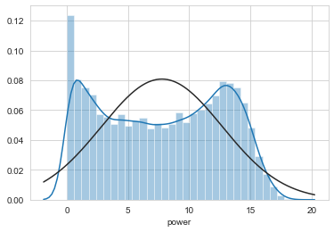

```python
sns.distplot(power_actual['power'], fit=norm); # Much better
```

```python
# 70080---> 27721
power_actual.describe()
```

|  | power |
| --- | --- |
| count | 27721.000000 |
| mean | 7.766025 |
| std | 4.936681 |
| min | 0.010000 |
| 25% | 3.130000 |
| 50% | 7.910000 |
| 75% | 12.250000 |
| max | 18.340000 |

```python
power_actual.shape # (27721, 2)
```

```
(27721, 2)
```

In power dataset preprocessing and data leaning step, we get only 27721 samples of data. (39.55% of data)

Data-preprocessing for weather attributes.

```python
# other datasets
weather_forecast= pd.read_csv("./weather_forecast.csv")
weather_actuals= pd.read_csv("./weather_actuals.csv")
weather_data = pd.concat([weather_actuals, weather_forecast])
weather_data.drop_duplicates()

weather_data.head()
```

|  | Unnamed: 0 | plant_id | datetime_utc | datetime_local | cloud_cover | apparent_temperature | temperature | humidity | dew_point | wind_bearing | wind_speed | wind_chill | wind_gust | heat_index | pressure | qpf | uv_index | snow | pop | fctcode | ozone | precip_accumulation | precip_intensity | precip_probability | precip_type | visibility | sunrise | sunset | icon | … |
| --- | --- | --- | --- | --- | --- | --- | --- | --- | --- | --- | --- | --- | --- | --- | --- | --- | --- | --- | --- | --- | --- | --- | --- | --- | --- | --- | --- | --- | --- | --- |
| 0 | 0 | 1 | 2017-09-30 18:30:00 | 2017-10-01 00:00:00 | 0.0 | 26.52 | 26 | 1 | 19.46 | 308 | 0.83 | -9999.0 | -9999.0 | -9999.0 | 1007.90 | -9999.0 | -9999 | -9999.0 | -9999.0 | -9999.0 | -9999.0 | -9999.0 | -9999.0 | -9999.0 | rain | 3.57 | 2017-10-01 00:52:02 | 2017-10-01 12:45:07 | clear-night | … |
| 1 | 1 | 1 | 2017-09-30 19:30:00 | 2017-10-01 01:00:00 | 0.0 | 28.78 | 27 | 1 | 20.06 | -9999 | -9999.00 | -9999.0 | -9999.0 | -9999.0 | -9999.00 | -9999.0 | -9999 | -9999.0 | -9999.0 | -9999.0 | -9999.0 | -9999.0 | -9999.0 | -9999.0 | rain | 3.06 | 2017-10-01 00:52:02 | 2017-10-01 12:45:07 | fog | … |
| 2 | 2 | 1 | 2017-09-30 20:30:00 | 2017-10-01 02:00:00 | 0.0 | 26.58 | 26 | 1 | 19.97 | -9999 | -9999.00 | -9999.0 | -9999.0 | -9999.0 | -9999.00 | -9999.0 | -9999 | -9999.0 | -9999.0 | -9999.0 | -9999.0 | -9999.0 | -9999.0 | -9999.0 | rain | 3.06 | 2017-10-01 00:52:02 | 2017-10-01 12:45:07 | fog | … |
| 3 | 3 | 1 | 2017-09-30 21:30:00 | 2017-10-01 03:00:00 | 0.0 | 23.84 | 23 | 1 | 18.66 | 270 | 0.45 | -9999.0 | -9999.0 | -9999.0 | 1008.12 | -9999.0 | -9999 | -9999.0 | -9999.0 | -9999.0 | -9999.0 | -9999.0 | -9999.0 | -9999.0 | rain | 3.56 | 2017-10-01 00:52:02 | 2017-10-01 12:45:07 | clear-night | … |
| 4 | 4 | 1 | 2017-09-30 22:30:00 | 2017-10-01 04:00:00 | 0.0 | 24.13 | 24 | 1 | 17.84 | -9999 | -9999.00 | -9999.0 | -9999.0 | -9999.0 | -9999.00 | -9999.0 | -9999 | -9999.0 | -9999.0 | -9999.0 | -9999.0 | -9999.0 | -9999.0 | -9999.0 | rain | 3.06 | 2017-10-01 00:52:02 | 2017-10-01 12:45:07 | fog | … |

```python
weather_data.describe()
```

|  | Unnamed: 0 | plant_id | cloud_cover | apparent_temperature | temperature | humidity | dew_point | wind_bearing | wind_speed | wind_chill | wind_gust | heat_index | pressure | qpf | uv_index | snow | pop | fctcode | ozone | precip_accumulation | precip_intensity | precip_probability | visibility |
| --- | --- | --- | --- | --- | --- | --- | --- | --- | --- | --- | --- | --- | --- | --- | --- | --- | --- | --- | --- | --- | --- | --- | --- |
| count | 14267.000000 | 14267.0 | 14267.000000 | 14267.000000 | 14267.000000 | 14267.000000 | 14267.000000 | 14267.000000 | 14267.000000 | 3744.0 | 14267.000000 | 3744.0 | 14267.000000 | 3744.0 | 14267.000000 | 3744.0 | 3744.0 | 3744.0 | 14267.000000 | 3744.0 | 14267.000000 | 14267.000000 | 14267.000000 |
| mean | 6514.431836 | 1.0 | -299.736972 | 26.018118 | 24.625429 | 0.536343 | 12.054735 | -469.474452 | -516.144857 | -9999.0 | -2284.329775 | -9999.0 | -654.335940 | -9999.0 | -2286.137801 | -9999.0 | -9999.0 | -9999.0 | -2075.838896 | -9999.0 | -2287.525605 | -2287.554770 | -111.037355 |
| std | 4071.954028 | 0.0 | 1705.781877 | 10.281513 | 8.710342 | 0.498695 | 8.972745 | 2502.881294 | 2218.040746 | 0.0 | 4201.962280 | 0.0 | 3942.883749 | 0.0 | 4200.977847 | 0.0 | 0.0 | 0.0 | 4315.540530 | 0.0 | 4200.221183 | 4200.205292 | 1105.131706 |
| min | 0.000000 | 1.0 | -9999.000000 | 3.140000 | 5.000000 | 0.000000 | -20.560000 | -9999.000000 | -9999.000000 | -9999.0 | -9999.000000 | -9999.0 | -9999.000000 | -9999.0 | -9999.000000 | -9999.0 | -9999.0 | -9999.0 | -9999.000000 | -9999.0 | -9999.000000 | -9999.000000 | -9999.000000 |
| 25% | 2918.500000 | 1.0 | 0.000000 | 17.780000 | 18.000000 | 0.000000 | 6.060000 | 77.000000 | 1.620000 | -9999.0 | 1.420000 | -9999.0 | 999.110000 | -9999.0 | 0.000000 | -9999.0 | -9999.0 | -9999.0 | 240.400000 | -9999.0 | 0.000000 | 0.000000 | 3.750000 |
| 50% | 6485.000000 | 1.0 | 0.000000 | 25.690000 | 25.000000 | 1.000000 | 11.110000 | 145.000000 | 2.390000 | -9999.0 | 3.070000 | -9999.0 | 1007.710000 | -9999.0 | 0.000000 | -9999.0 | -9999.0 | -9999.0 | 271.500000 | -9999.0 | 0.000000 | 0.000000 | 16.090000 |
| 75% | 10051.500000 | 1.0 | 0.400000 | 34.300000 | 31.000000 | 1.000000 | 19.325000 | 293.000000 | 3.290000 | -9999.0 | 4.670000 | -9999.0 | 1014.520000 | -9999.0 | 2.000000 | -9999.0 | -9999.0 | -9999.0 | 280.400000 | -9999.0 | 0.000000 | 0.000000 | 16.090000 |
| max | 13618.000000 | 1.0 | 1.000000 | 49.750000 | 47.000000 | 1.000000 | 28.350000 | 359.000000 | 9.730000 | -9999.0 | 15.150000 | -9999.0 | 1025.690000 | -9999.0 | 12.000000 | -9999.0 | -9999.0 | -9999.0 | 351.700000 | -9999.0 | 6.220000 | 0.730000 | 16.090000 |

### Observations:

1. Clearly, datasets has some irrevelant feature/common variables that can be dropped and have some independent variable, that will not impart any knowledge to model. Example: plant_id=1, it shows the data has been collected from same sources. updated_at may be irrelevant.
2. Here, -9999. and -9999.00 are -inf values that need to be processed.
3. Out of two datetime feature above, datetime_local seems to match the same in power dataset, so we will inner join on this features, to merge and get the complete datasets.
4. Some Features distribution here highly skewed.

```python
# Observations #1: drop columns
weather_data.columns.values
irrevalent_col = ['Unnamed: 0', 'plant_id', 'datetime_utc','updated_at']
no_feature = ['wind_chill','heat_index', 'qpf','snow','pop', 'fctcode','precip_accumulation','precip_intensity']

weather_data.drop(columns=irrevalent_col,inplace=True)
weather_data.drop(columns=no_feature,inplace=True)
```

### Datetime and Categorical data description

### Observations:

1. Feature precip_type has 6261/6604 values of rain (94.80 %). It can be treated as same values contributions for all features. We may drop this columns.
2. Datetime feature: datetime_local, sunrise and sunset are be higly correlated as it is recorded on same day and may not impart different knowledge to model.
3. Icon and summary sahre same semantics. One of them may be dropped.
4. Handling -inf values may be tricky as the independent values seems higly correlated.

```python
weather_data.describe(include="O")
```

|  | datetime_local | precip_type | sunrise | sunset | icon | summary |
| --- | --- | --- | --- | --- | --- | --- |
| count | 14267 | 6604 | 14267 | 14267 | 14267 | 14267 |
| unique | 14267 | 2 | 595 | 595 | 8 | 19 |
| top | 2018-12-13 06:00:00 | rain | 2019-07-06 00:05:48 | 2018-08-18 13:36:37 | clear-night | Clear |
| freq | 1 | 6261 | 24 | 24 | 3340 | 6057 |

```python
# Observations #1.
weather_data.drop(columns=["precip_type"],inplace=True)
```

```python
# Observations #4

# find out column wise values -infinity values
tst = weather_data.copy(True)
for col in tst.columns.values:
    tst_col = tst[col]
    tst_col = tst_col[(tst_col==-9999) | (tst_col==-9999.00 )].dropna()
    print(col,len(tst_col))
```

```
datetime_local 0
cloud_cover 428
apparent_temperature 0
temperature 0
humidity 0
dew_point 0
wind_bearing 919
wind_speed 740
wind_gust 3264
pressure 2156
uv_index 3264
ozone 3264
precip_probability 3264
visibility 176
sunrise 0
sunset 0
icon 0
summary 0
```

```python
print(weather_data.shape)
# as seen above, let us clear small -inf values is in feature like cloud cover, visibility. we can drop values.
weather_data = weather_data[weather_data["cloud_cover"]!=-9999.0]
weather_data = weather_data[weather_data["visibility"]!=-9999.0]
weather_data = weather_data[weather_data["precip_probability"]!=-9999.0]
print(weather_data.shape) # loss in 3,440 rows
```

```
(14267, 18)
(10827, 18)
```

```python
# before, we go further cleaning of values, lets see
weather_data.describe()
```

|  | cloud_cover | apparent_temperature | temperature | humidity | dew_point | wind_bearing | wind_speed | wind_gust | pressure | uv_index | ozone | precip_probability | visibility |
| --- | --- | --- | --- | --- | --- | --- | --- | --- | --- | --- | --- | --- | --- |
| count | 10827.000000 | 10827.000000 | 10827.000000 | 10827.000000 | 10827.000000 | 10827.000000 | 10827.000000 | 10827.000000 | 10827.000000 | 10827.000000 | 10827.000000 | 10827.000000 | 10827.000000 |
| mean | 0.283241 | 28.248811 | 26.429574 | 0.490163 | 12.573817 | 174.432715 | 2.806937 | 4.206692 | 1008.584177 | 1.856008 | 274.166885 | 0.017693 | 15.610646 |
| std | 0.360819 | 10.020269 | 8.329938 | 0.499926 | 9.900278 | 112.345011 | 1.189562 | 2.164166 | 7.673111 | 2.905026 | 14.567197 | 0.054522 | 2.384651 |
| min | 0.000000 | 4.310000 | 6.000000 | 0.000000 | -20.560000 | 0.000000 | 0.070000 | 0.630000 | 991.660000 | 0.000000 | 225.800000 | 0.000000 | 0.000000 |
| 25% | 0.000000 | 20.385000 | 20.000000 | 0.000000 | 5.445000 | 83.000000 | 1.930000 | 2.670000 | 1001.770000 | 0.000000 | 268.100000 | 0.000000 | 16.090000 |
| 50% | 0.050000 | 29.080000 | 28.000000 | 0.000000 | 11.900000 | 137.000000 | 2.600000 | 3.690000 | 1009.040000 | 0.000000 | 275.500000 | 0.000000 | 16.090000 |
| 75% | 0.560000 | 36.200000 | 32.000000 | 1.000000 | 22.200000 | 295.000000 | 3.470000 | 5.290000 | 1014.890000 | 3.000000 | 282.900000 | 0.010000 | 16.090000 |
| max | 1.000000 | 49.750000 | 47.000000 | 1.000000 | 28.350000 | 359.000000 | 9.730000 | 15.150000 | 1025.690000 | 12.000000 | 351.700000 | 0.730000 | 16.090000 |

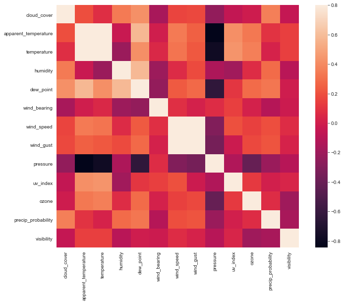

```python
#correlation matrix
corrmat = weather_data.corr()
f, ax = plt.subplots(figsize=(12, 9))
sns.heatmap(corrmat, vmax=.8, square=True);
```

Above Heatmap shows there is high correlation between apparent_temp & temp and wind_speed & wind_gust, we may drop one of the attributes.

```python
weather_data.drop(columns=["apparent_temperature","wind_gust"],inplace=True)
print(weather_data.shape)
```

```
(10827, 16)
```

## Categorical Data Handling

```python
weather_data.describe(include="O")
```

|  | datetime_local | sunrise | sunset | icon | summary |
| --- | --- | --- | --- | --- | --- |
| count | 10827 | 10827 | 10827 | 10827 | 10827 |
| unique | 10827 | 453 | 453 | 7 | 18 |
| top | 2018-12-13 06:00:00 | 2019-07-06 00:05:48 | 2018-08-18 13:36:37 | clear-night | Clear |
| freq | 1 | 24 | 24 | 3098 | 5434 |

```python
#icon and summary has alomost same semantics,we may drop summary features as it will simple and less descriptive.
icon_value = weather_data["icon"].unique()
summary_value = weather_data["summary"].unique()

#see the data values of Icon & Summary
print(icon_value)
print(summary_value)

weather_data[["icon","summary"]].head(5)

weather_data.drop(columns=["summary"],inplace=True)
```

```
['fog' 'partly-cloudy-day' 'clear-day' 'clear-night' 'partly-cloudy-night'
 'cloudy' 'rain']
['Foggy' 'Partly Cloudy' 'Clear' 'Mostly Cloudy' 'Overcast'
 'Humid and Partly Cloudy' 'Humid and Mostly Cloudy' 'Humid and Overcast'
 'Humid and Foggy' 'Possible Light Rain and Humid' 'Humid'
 'Possible Light Rain' 'Rain' 'Light Rain' 'Light Rain and Humid'
 'Possible Drizzle and Humid' 'Rain and Humid' 'Possible Drizzle']
```

```python
# processing icon attributes: Lets see the frequency distribution
weather_data["icon"].value_counts()
```

```
clear-night            3098
clear-day              2841
partly-cloudy-day      1784
partly-cloudy-night    1492
cloudy                 1327
fog                     191
rain                     94
Name: icon, dtype: int64
```

```python
# depending on the frequency of values, we may choose below map dcitionary.
# This is neccessay step as we need numerical data to feed into respective model.
icon_mapping = {"clear-day":1,"clear-night":1,"partly-cloudy-day":2,"partly-cloudy-night":2,"cloudy":2,"fog":3,"rain":4}

weather_data['icon'] = weather_data['icon'].map(icon_mapping)
```

```python
# how the values is dirtribued now.
weather_data["icon"].value_counts()
```

```
1    5939
2    4603
3     191
4      94
Name: icon, dtype: int64
```

dealing with datetime

```python
def extract(data,column,keyword):
    """
    function to split the datetime column into respective year,month, day amd hour
    """
    data[keyword+"_year"] = data[column].dt.year
    data[keyword+"_month"] = data[column].dt.month
    data[keyword+"_day"] = data[column].dt.day
    data[keyword+"_hour"] = data[column].dt.hour

# conversions
weather_data["datetime_local"] = pd.to_datetime(weather_data["datetime_local"])
weather_data["sunrise"] = pd.to_datetime(weather_data["sunrise"])
weather_data["sunset"] = pd.to_datetime(weather_data["sunset"])


extract(weather_data,"datetime_local","dl")
extract(weather_data,"sunset","ss")
extract(weather_data,"sunrise","sr")

weather_data.head()
```

|  | datetime_local | cloud_cover | temperature | humidity | dew_point | wind_bearing | wind_speed | pressure | uv_index | ozone | precip_probability | visibility | sunrise | sunset | icon | dl_year | dl_month | dl_day | dl_hour | ss_year | ss_month | ss_day | ss_hour | sr_year | sr_month | sr_day | sr_hour |
| --- | --- | --- | --- | --- | --- | --- | --- | --- | --- | --- | --- | --- | --- | --- | --- | --- | --- | --- | --- | --- | --- | --- | --- | --- | --- | --- | --- |
| 3264 | 2018-02-14 00:00:00 | 0.11 | 14 | 1 | 8.19 | 335 | 1.70 | 1024.00 | 0 | 335.82 | 0.00 | 1.88 | 2018-02-14 01:38:46 | 2018-02-14 12:47:51 | 3 | 2018 | 2 | 14 | 0 | 2018 | 2 | 14 | 12 | 2018 | 2 | 14 | 1 |
| 3265 | 2018-02-14 01:00:00 | 0.00 | 14 | 1 | 8.82 | 307 | 2.52 | 1023.93 | 0 | 333.09 | 0.00 | 2.57 | 2018-02-14 01:38:46 | 2018-02-14 12:47:51 | 3 | 2018 | 2 | 14 | 1 | 2018 | 2 | 14 | 12 | 2018 | 2 | 14 | 1 |
| 3266 | 2018-02-14 02:00:00 | 0.00 | 14 | 1 | 9.07 | 318 | 2.88 | 1023.86 | 0 | 330.29 | 0.01 | 2.57 | 2018-02-14 01:38:46 | 2018-02-14 12:47:51 | 3 | 2018 | 2 | 14 | 2 | 2018 | 2 | 14 | 12 | 2018 | 2 | 14 | 1 |
| 3267 | 2018-02-14 03:00:00 | 0.09 | 12 | 1 | 9.24 | 322 | 1.15 | 1024.28 | 0 | 328.21 | 0.01 | 1.90 | 2018-02-14 01:38:46 | 2018-02-14 12:47:51 | 3 | 2018 | 2 | 14 | 3 | 2018 | 2 | 14 | 12 | 2018 | 2 | 14 | 1 |
| 3268 | 2018-02-14 04:00:00 | 0.00 | 13 | 1 | 9.31 | 297 | 2.51 | 1023.72 | 0 | 326.80 | 0.01 | 2.57 | 2018-02-14 01:38:46 | 2018-02-14 12:47:51 | 3 | 2018 | 2 | 14 | 4 | 2018 | 2 | 14 | 12 | 2018 | 2 | 14 | 1 |

## Merge and Clean More data

```python
# converting power dateset datetime_local to datetime data type
power_actual["datetime_local"] = pd.to_datetime(power_actual["datetime_local"])
power_actual.info()
```

```
<class 'pandas.core.frame.DataFrame'>
Int64Index: 27721 entries, 27 to 69959
Data columns (total 2 columns):
 #   Column          Non-Null Count  Dtype
---  ------          --------------  -----
 0   datetime_local  27721 non-null  datetime64[ns]
 1   power           27721 non-null  float64
dtypes: datetime64[ns](1), float64(1)
memory usage: 649.7 KB
```

```python
# merge the date over common datetime_local features
merged_data = weather_data.merge(power_actual,on="datetime_local")
merged_data.shape # (4006, 28)
```

```
(4006, 28)
```

```python
# drop the others columns, that we dont need now
merged_data.drop(columns=["sunset","sunrise","datetime_local"],inplace=True)
```

```python
merged_data.head()
```

|  | cloud_cover | temperature | humidity | dew_point | wind_bearing | wind_speed | pressure | uv_index | ozone | precip_probability | visibility | icon | dl_year | dl_month | dl_day | dl_hour | ss_year | ss_month | ss_day | ss_hour | sr_year | sr_month | sr_day | sr_hour | power |
| --- | --- | --- | --- | --- | --- | --- | --- | --- | --- | --- | --- | --- | --- | --- | --- | --- | --- | --- | --- | --- | --- | --- | --- | --- | --- |
| 0 | 0.00 | 8 | 1 | 7.21 | 264 | 2.15 | 1023.64 | 0 | 322.87 | 0.0 | 0.48 | 3 | 2018 | 2 | 14 | 7 | 2018 | 2 | 14 | 12 | 2018 | 2 | 14 | 1 | 0.01 |
| 1 | 0.00 | 8 | 1 | 7.79 | 267 | 1.39 | 1023.98 | 1 | 320.89 | 0.0 | 0.00 | 3 | 2018 | 2 | 14 | 8 | 2018 | 2 | 14 | 12 | 2018 | 2 | 14 | 1 | 2.54 |
| 2 | 0.24 | 11 | 1 | 8.68 | 289 | 1.13 | 1024.57 | 1 | 318.71 | 0.0 | 2.08 | 3 | 2018 | 2 | 14 | 9 | 2018 | 2 | 14 | 12 | 2018 | 2 | 14 | 1 | 7.88 |
| 3 | 0.00 | 13 | 1 | 8.80 | 273 | 3.54 | 1024.27 | 2 | 316.27 | 0.0 | 0.80 | 3 | 2018 | 2 | 14 | 10 | 2018 | 2 | 14 | 12 | 2018 | 2 | 14 | 1 | 11.78 |
| 4 | 0.00 | 18 | 1 | 8.79 | 282 | 4.43 | 1024.28 | 4 | 313.30 | 0.0 | 1.77 | 3 | 2018 | 2 | 14 | 11 | 2018 | 2 | 14 | 12 | 2018 | 2 | 14 | 1 | 14.78 |

```python
merged_data.describe()
```

|  | cloud_cover | temperature | humidity | dew_point | wind_bearing | wind_speed | pressure | uv_index | ozone | precip_probability | visibility | icon | dl_year | dl_month | dl_day | dl_hour | ss_year | ss_month | ss_day | ss_hour | sr_year | sr_month | sr_day | sr_hour | power |
| --- | --- | --- | --- | --- | --- | --- | --- | --- | --- | --- | --- | --- | --- | --- | --- | --- | --- | --- | --- | --- | --- | --- | --- | --- | --- |
| count | 4006.000000 | 4006.000000 | 4006.000000 | 4006.000000 | 4006.000000 | 4006.000000 | 4006.000000 | 4006.000000 | 4006.000000 | 4006.000000 | 4006.000000 | 4006.000000 | 4006.000000 | 4006.000000 | 4006.000000 | 4006.000000 | 4006.000000 | 4006.000000 | 4006.000000 | 4006.000000 | 4006.000000 | 4006.000000 | 4006.000000 | 4006.000000 | 4006.000000 |
| mean | 0.280052 | 28.716425 | 0.384673 | 12.238767 | 197.497753 | 3.011453 | 1009.017596 | 4.041687 | 274.359905 | 0.015497 | 15.625729 | 1.464803 | 2018.636545 | 6.516975 | 15.801298 | 11.975287 | 2018.636545 | 6.516975 | 15.801298 | 12.618822 | 2018.636545 | 6.516975 | 15.801298 | 0.413630 | 8.050469 |
| std | 0.362438 | 8.091793 | 0.486579 | 9.735819 | 109.486154 | 1.324262 | 7.807549 | 3.133805 | 15.039068 | 0.044171 | 2.375713 | 0.544760 | 0.481054 | 3.390754 | 8.602091 | 3.189737 | 0.481054 | 3.390754 | 8.602091 | 0.596900 | 0.481054 | 3.390754 | 8.602091 | 0.492545 | 4.920340 |
| min | 0.000000 | 7.000000 | 0.000000 | -16.180000 | 0.000000 | 0.150000 | 992.230000 | 0.000000 | 228.200000 | 0.000000 | 0.000000 | 1.000000 | 2018.000000 | 1.000000 | 1.000000 | 6.000000 | 2018.000000 | 1.000000 | 1.000000 | 12.000000 | 2018.000000 | 1.000000 | 1.000000 | 0.000000 | 0.010000 |
| 25% | 0.000000 | 22.000000 | 0.000000 | 5.372500 | 102.000000 | 2.010000 | 1002.132500 | 1.000000 | 267.900000 | 0.000000 | 16.090000 | 1.000000 | 2018.000000 | 4.000000 | 8.000000 | 9.000000 | 2018.000000 | 4.000000 | 8.000000 | 12.000000 | 2018.000000 | 4.000000 | 8.000000 | 0.000000 | 3.630000 |
| 50% | 0.050000 | 30.000000 | 0.000000 | 11.110000 | 204.000000 | 2.800000 | 1008.860000 | 4.000000 | 275.700000 | 0.000000 | 16.090000 | 1.000000 | 2019.000000 | 7.000000 | 16.000000 | 12.000000 | 2019.000000 | 7.000000 | 16.000000 | 13.000000 | 2019.000000 | 7.000000 | 16.000000 | 0.000000 | 8.295000 |
| 75% | 0.560000 | 35.000000 | 1.000000 | 21.485000 | 303.000000 | 3.770000 | 1015.630000 | 6.000000 | 284.000000 | 0.010000 | 16.090000 | 2.000000 | 2019.000000 | 9.000000 | 23.000000 | 15.000000 | 2019.000000 | 9.000000 | 23.000000 | 13.000000 | 2019.000000 | 9.000000 | 23.000000 | 1.000000 | 12.467500 |
| max | 1.000000 | 47.000000 | 1.000000 | 28.350000 | 359.000000 | 9.730000 | 1025.690000 | 12.000000 | 333.200000 | 0.650000 | 16.090000 | 4.000000 | 2019.000000 | 12.000000 | 31.000000 | 17.000000 | 2019.000000 | 12.000000 | 31.000000 | 14.000000 | 2019.000000 | 12.000000 | 31.000000 | 1.000000 | 18.340000 |

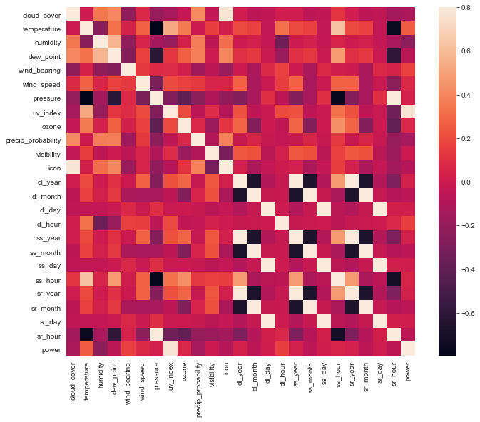

```python
#correlation matrix
corrmat = merged_data.corr()
f, ax = plt.subplots(figsize=(12, 9))
sns.heatmap(corrmat, vmax=.8, square=True);
```

### Observations:

clearly, there is some highly expected correlation between:

1. icon and cloud_cover.
2. for day, month and year features of sunrise and sunset to the same of datetime_local.
3. sr_hour and pressure.

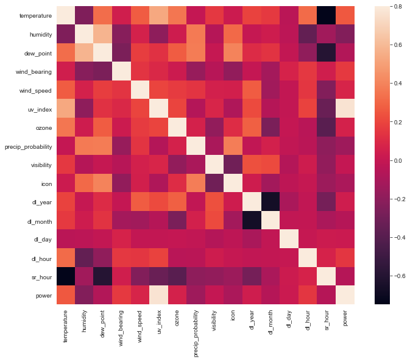

```python
merged_data.drop(columns=["sr_year","ss_year","ss_month","ss_hour","sr_month","ss_day","sr_day"],inplace=True)
merged_data.drop(columns=["cloud_cover","pressure"],inplace=True)

#correlation matrix
corrmat = merged_data.corr()
f, ax = plt.subplots(figsize=(12, 9))
sns.heatmap(corrmat, vmax=.8, square=True);
```

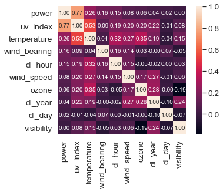

```python
k = 10 #number of variables for heatmap
corrmat = merged_data.corr()
cols = corrmat.nlargest(k, 'power')['power'].index
cm = np.corrcoef(merged_data[cols].values.T)
sns.set(font_scale=1.25)
hm = sns.heatmap(cm, cbar=True, annot=True, square=True, fmt='.2f', annot_kws={'size': 10}, yticklabels=cols.values, xticklabels=cols.values)
plt.show()
```

```python
# Towards Normality of featues again.
merged_data.skew()
```

```
temperature          -0.345124
humidity              0.474269
dew_point            -0.159220
wind_bearing         -0.142614
wind_speed            0.913135
uv_index              0.607365
ozone                -0.399840
precip_probability    5.405854
visibility           -5.170008
icon                  0.686747
dl_year              -0.567975
dl_month             -0.051770
dl_day               -0.046181
dl_hour              -0.035793
sr_hour               0.350886
power                -0.057683
dtype: float64
```

The above list show features: visibility and precip_probability has higher degree of skewness which may make model difficult to find optimal hyperspace descent.

```python
# visibility fetaures
print(merged_data["visibility"].value_counts())
# Out of 3834/4006 (95.70 % ), "visibility" has 16.09 values. Clearly, We can drop this feature too.

print(merged_data["precip_probability"].value_counts())
# Out of 2910/4006 (72.64 % ) "precip_probability" has 0.00 values. Clearly, We can drop this feature too.
```

```
16.09    3834
3.54       21
4.02       11
2.57        8
1.45        7
         ...
15.63       1
9.32        1
4.78        1
15.27       1
0.00        1
Name: visibility, Length: 99, dtype: int64
0.00    2910
0.01     289
0.02     173
0.03     125
0.04      96
0.05      76
0.06      48
0.07      41
0.08      31
0.09      31
0.10      22
0.11      21
0.13      19
0.12      13
0.18      11
0.21      10
0.19       9
0.16       9
0.20       9
0.15       8
0.22       8
0.17       7
0.14       6
0.26       6
0.24       5
0.30       3
0.25       3
0.27       2
0.23       2
0.28       2
0.62       1
0.50       1
0.37       1
0.31       1
0.29       1
0.39       1
0.33       1
0.65       1
0.59       1
0.38       1
0.36       1
Name: precip_probability, dtype: int64
```

```python
#dropping the columns
merged_data.drop(columns=["visibility","precip_probability"],inplace=True)
```

```python
# merged_data.drop(columns=["sunset","sunrise","datetime_local"],inplace=True)
merged_data.head()
```

|  | temperature | humidity | dew_point | wind_bearing | wind_speed | uv_index | ozone | icon | dl_year | dl_month | dl_day | dl_hour | sr_hour | power |
| --- | --- | --- | --- | --- | --- | --- | --- | --- | --- | --- | --- | --- | --- | --- |
| 0 | 8 | 1 | 7.21 | 264 | 2.15 | 0 | 322.87 | 3 | 2018 | 2 | 14 | 7 | 1 | 0.01 |
| 1 | 8 | 1 | 7.79 | 267 | 1.39 | 1 | 320.89 | 3 | 2018 | 2 | 14 | 8 | 1 | 2.54 |
| 2 | 11 | 1 | 8.68 | 289 | 1.13 | 1 | 318.71 | 3 | 2018 | 2 | 14 | 9 | 1 | 7.88 |
| 3 | 13 | 1 | 8.80 | 273 | 3.54 | 2 | 316.27 | 3 | 2018 | 2 | 14 | 10 | 1 | 11.78 |
| 4 | 18 | 1 | 8.79 | 282 | 4.43 | 4 | 313.30 | 3 | 2018 | 2 | 14 | 11 | 1 | 14.78 |

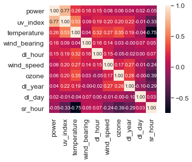

```python
# lets see the final heatmap before feeding to model
k = 10 #number of variables for heatmap
corrmat = merged_data.corr()
cols = corrmat.nlargest(k, 'power')['power'].index
cm = np.corrcoef(merged_data[cols].values.T)
sns.set(font_scale=1.25)
hm = sns.heatmap(cm, cbar=True, annot=True, square=True, fmt='.2f', annot_kws={'size': 10}, yticklabels=cols.values, xticklabels=cols.values)
plt.show()
```

Good to go to Model Step!!

```python
# data preparing before feeding to model
columns = list(merged_data.columns.values)
idx = columns.remove("power")

X = np.array(merged_data[columns])
y = np.array(merged_data["power"])

from sklearn.model_selection import train_test_split
X_train, X_test, y_train, y_test = train_test_split(X, y, test_size=0.3, random_state=101)
```

```python
# Helper function
n_folds = 5

scorer = make_scorer(mean_squared_error, greater_is_better = False)

def rmsle_cv(model):
    kf = KFold(n_folds, shuffle=True, random_state=42).get_n_splits(X_train)
    rmse= np.sqrt(-cross_val_score(model, X_train, y_train, scoring="neg_mean_squared_error", cv = kf))
    return(rmse)

def get_train_val_metrics(model):
    train = rmse_cv_train(model)
    test = rmse_cv_test(model)
    return train, test

def rmse_cv_train(model):
    kf = KFold(n_folds, shuffle=True, random_state=42).get_n_splits(X_train)
    rmse= np.sqrt(-cross_val_score(model, X_train, y_train, scoring = scorer, cv = kf))
    return(rmse)

def rmse_cv_test(model):
    kf = KFold(n_folds, shuffle=True, random_state=42).get_n_splits(X_test)
    rmse= np.sqrt(-cross_val_score(model, X_test, y_test, scoring = scorer, cv = kf))
    return(rmse)

# Avraging models
class AveragingModels(BaseEstimator, RegressorMixin, TransformerMixin):
    def __init__(self, models):
        self.models = models

    # we define clones of the original models to fit the data in
    def fit(self, X, y):
        self.models_ = [clone(x) for x in self.models]

        # Train cloned base models
        for model in self.models_:
            model.fit(X, y)

        return self

    #Now we do the predictions for cloned models and average them
    def predict(self, X):
        predictions = np.column_stack([
            model.predict(X) for model in self.models_
        ])
        return np.mean(predictions, axis=1)

def plot_predictions(y_train_pred,y_train,y_test_pred,y_test):
    """Plot predictions"""
    """to plot the variation from prediction values"""
    plt.scatter(y_train_pred, y_train, c = "blue", marker = "s", label = "Training data")
    plt.scatter(y_test_pred, y_test, c = "lightgreen", marker = "s", label = "Validation data")
    plt.title("Linear regression")
    plt.xlabel("Predicted values")
    plt.ylabel("Real values")
    plt.legend(loc = "upper left")
    plt.plot([10.5, 13.5], [10.5, 13.5], c = "red")
    plt.show()

def plot_coeff(model,columns):
    """Plot important coefficients"""
    coefs = pd.Series(model.coef_, index = columns)
    print("Ridge picked " + str(sum(coefs != 0)) + " features and eliminated the other " +  \
          str(sum(coefs == 0)) + " features")
    imp_coefs = pd.concat([coefs.sort_values().head(10),
                         coefs.sort_values().tail(10)])
    imp_coefs.plot(kind = "barh")
    plt.title("Coefficients in the Ridge Model")
    plt.show()
```

```
RMSE on Training set : 2.911877373528596
RMSE on Test set : 2.829273183688079
```

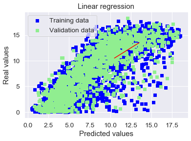

```python
# Linear Regression
lr = LinearRegression()
lr.fit(X_train, y_train)
# Look at predictions on training and validation set
print("RMSE on Training set :", rmse_cv_train(lr).mean())
print("RMSE on Test set :", rmse_cv_test(lr).mean())
y_train_pred = lr.predict(X_train)
y_test_pred = lr.predict(X_test)

plot_predictions(y_train_pred,y_train,y_test_pred,y_test)
```

```
Best alpha : 10.0
Try again for more precision with alphas centered around 10.0
Best alpha : 9.0
Ridge RMSE on Training set : 2.9120007087040447
Ridge RMSE on Test set : 2.829345351990688
```

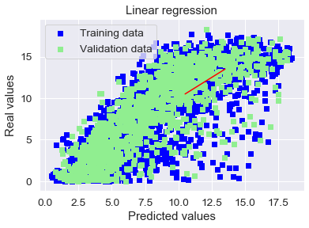

```
Ridge picked 13 features and eliminated the other 0 features
```

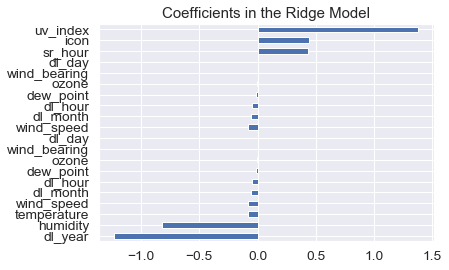

```python
# 2* Ridge
ridge = RidgeCV(alphas = [0.01, 0.03, 0.06, 0.1, 0.3, 0.6, 1, 3, 6, 10, 30, 60])
ridge.fit(X_train, y_train)
alpha = ridge.alpha_
print("Best alpha :", alpha)

print("Try again for more precision with alphas centered around " + str(alpha))
ridge = RidgeCV(alphas = [alpha * .6, alpha * .65, alpha * .7, alpha * .75, alpha * .8, alpha * .85,
                          alpha * .9, alpha * .95, alpha, alpha * 1.05, alpha * 1.1, alpha * 1.15,
                          alpha * 1.25, alpha * 1.3, alpha * 1.35, alpha * 1.4],
                cv = 10)
ridge.fit(X_train, y_train)
alpha = ridge.alpha_
print("Best alpha :", alpha)

print("Ridge RMSE on Training set :", rmse_cv_train(ridge).mean())
print("Ridge RMSE on Test set :", rmse_cv_test(ridge).mean())
y_train_rdg = ridge.predict(X_train)
y_test_rdg = ridge.predict(X_test)

plot_predictions(y_train_pred,y_train,y_test_pred,y_test)


plot_coeff(ridge,columns)
```

```
Best alpha : 0.0001
Try again for more precision with alphas centered around 0.0001
Best alpha : 6e-05
Lasso RMSE on Training set : 2.9118797324135643
Lasso RMSE on Test set : 2.8292562539237602
```

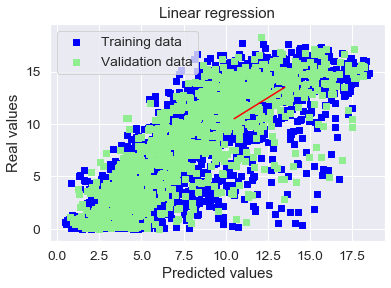

```
Ridge picked 13 features and eliminated the other 0 features
```

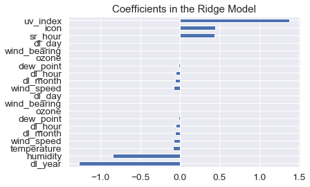

```python
# 3* Lasso
lasso = LassoCV(alphas = [0.0001, 0.0003, 0.0006, 0.001, 0.003, 0.006, 0.01, 0.03, 0.06, 0.1,
                          0.3, 0.6, 1],
                max_iter = 50000, cv = 10)
lasso.fit(X_train, y_train)
alpha = lasso.alpha_
print("Best alpha :", alpha)

print("Try again for more precision with alphas centered around " + str(alpha))
lasso = LassoCV(alphas = [alpha * .6, alpha * .65, alpha * .7, alpha * .75, alpha * .8,
                          alpha * .85, alpha * .9, alpha * .95, alpha, alpha * 1.05,
                          alpha * 1.1, alpha * 1.15, alpha * 1.25, alpha * 1.3, alpha * 1.35,
                          alpha * 1.4],
                max_iter = 50000, cv = 10)
lasso.fit(X_train, y_train)
alpha = lasso.alpha_
print("Best alpha :", alpha)

print("Lasso RMSE on Training set :", rmse_cv_train(lasso).mean())
print("Lasso RMSE on Test set :", rmse_cv_test(lasso).mean())
y_train_las = lasso.predict(X_train)
y_test_las = lasso.predict(X_test)

plot_predictions(y_train_las, y_train,y_test_las, y_test)
plot_coeff(lasso,columns)
```

```
Best l1_ratio : 0.1
Best alpha : 0.003
Try again for more precision with l1_ratio centered around 0.1
Best l1_ratio : 0.085
Best alpha : 0.003
Now try again for more precision on alpha, with l1_ratio fixed at 0.085 and alpha centered around 0.003
Best l1_ratio : 0.085
Best alpha : 0.00315
ElasticNet RMSE on Training set : 2.9119194203508405
ElasticNet RMSE on Test set : 2.829119068510667
```

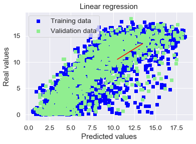

```
Ridge picked 13 features and eliminated the other 0 features
```

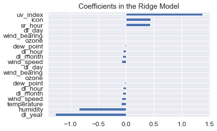

```python
# 4* ElasticNet
elasticNet = ElasticNetCV(l1_ratio = [0.1, 0.3, 0.5, 0.6, 0.7, 0.8, 0.85, 0.9, 0.95, 1],
                          alphas = [0.0001, 0.0003, 0.0006, 0.001, 0.003, 0.006,
                                    0.01, 0.03, 0.06, 0.1, 0.3, 0.6, 1, 3, 6],
                          max_iter = 50000, cv = 10)
elasticNet.fit(X_train, y_train)
alpha = elasticNet.alpha_
ratio = elasticNet.l1_ratio_
print("Best l1_ratio :", ratio)
print("Best alpha :", alpha )

print("Try again for more precision with l1_ratio centered around " + str(ratio))
elasticNet = ElasticNetCV(l1_ratio = [ratio * .85, ratio * .9, ratio * .95, ratio, ratio * 1.05, ratio * 1.1, ratio * 1.15],
                          alphas = [0.0001, 0.0003, 0.0006, 0.001, 0.003, 0.006, 0.01, 0.03, 0.06, 0.1, 0.3, 0.6, 1, 3, 6],
                          max_iter = 50000, cv = 10)
elasticNet.fit(X_train, y_train)
if (elasticNet.l1_ratio_ > 1):
    elasticNet.l1_ratio_ = 1
alpha = elasticNet.alpha_
ratio = elasticNet.l1_ratio_
print("Best l1_ratio :", ratio)
print("Best alpha :", alpha )

print("Now try again for more precision on alpha, with l1_ratio fixed at " + str(ratio) +
      " and alpha centered around " + str(alpha))
elasticNet = ElasticNetCV(l1_ratio = ratio,
                          alphas = [alpha * .6, alpha * .65, alpha * .7, alpha * .75, alpha * .8, alpha * .85, alpha * .9,
                                    alpha * .95, alpha, alpha * 1.05, alpha * 1.1, alpha * 1.15, alpha * 1.25, alpha * 1.3,
                                    alpha * 1.35, alpha * 1.4],
                          max_iter = 50000, cv = 10)
elasticNet.fit(X_train, y_train)
if (elasticNet.l1_ratio_ > 1):
    elasticNet.l1_ratio_ = 1
alpha = elasticNet.alpha_
ratio = elasticNet.l1_ratio_
print("Best l1_ratio :", ratio)
print("Best alpha :", alpha )

print("ElasticNet RMSE on Training set :", rmse_cv_train(elasticNet).mean())
print("ElasticNet RMSE on Test set :", rmse_cv_test(elasticNet).mean())
y_train_ela = elasticNet.predict(X_train)
y_test_ela = elasticNet.predict(X_test)

plot_predictions(y_train_ela,y_train, y_test_ela,y_test)
plot_coeff(lasso,columns)
```

```python
# some other popular model used in solving Regression Problem.
KRR = KernelRidge(alpha=0.6, kernel='polynomial', degree=2, coef0=2.5)

GBoost = GradientBoostingRegressor(n_estimators=3000, learning_rate=0.05,
                                   max_depth=4, max_features='sqrt',
                                   min_samples_leaf=15, min_samples_split=10,
                                   loss='huber', random_state =5)

model_xgb = xgb.XGBRegressor(colsample_bytree=0.4603, gamma=0.0468,
                             learning_rate=0.05, max_depth=3,
                             min_child_weight=1.7817, n_estimators=2200,
                             reg_alpha=0.4640, reg_lambda=0.8571,
                             subsample=0.5213, silent=1,
                             random_state =7, nthread = -1)

model_lgb = lgb.LGBMRegressor(objective='regression',num_leaves=5,
                              learning_rate=0.05, n_estimators=720,
                              max_bin = 55, bagging_fraction = 0.8,
                              bagging_freq = 5, feature_fraction = 0.2319,
                              feature_fraction_seed=9, bagging_seed=9,
                              min_data_in_leaf =6, min_sum_hessian_in_leaf = 11)

models = [KRR,GBoost,model_xgb]
model_names = ["KRR","GBoost","model_xgb"]
print("RMSE Error Model wise")
for model_name,model in zip(model_names,models):
    train_score,val_score = get_train_val_metrics(model)
    print("{} Train score: {:.6f} ({:.6f})".format(model_name,train_score.mean(), train_score.std()))
    print("{} Val score: {:.6f} ({:.6f})".format(model_name,val_score.mean(), val_score.std()))
    print("**"*10)
```

```
RMSE Error Model wise
KRR Train score: 2.276441 (0.146533)
KRR Val score: 2.251799 (0.193634)
GBoost Train score: 2.091455 (0.121218)
GBoost Val score: 2.336761 (0.182148)
model_xgb Train score: 2.152704 (0.120692)
model_xgb Val score: 2.347582 (0.192533)
```

```python
averaged_models = AveragingModels(models = (GBoost, KRR, lasso))

score = rmsle_cv(averaged_models)
print(" Averaged base models score: {:.6f} ({:.6f})\n".format(score.mean(), score.std()))
```

```
 Averaged base models score: 2.219057 (0.148312)
```

### Models Vs RMSE loss

[output not shown]

```python
y_pred = best_model.predict(X_test)
df = pd.DataFrame({'Actual': np.array(y_test).flatten(), 'Predicted': y_pred.flatten()})
df.head(20)
```

|  | Actual | Predicted |
| --- | --- | --- |
| 0 | 6.19 | 5.718504 |
| 1 | 7.91 | 8.809799 |
| 2 | 8.64 | 6.718351 |
| 3 | 10.56 | 10.746400 |
| 4 | 4.62 | 3.263065 |
| 5 | 16.00 | 16.302073 |
| 6 | 8.15 | 6.262700 |
| 7 | 0.24 | 0.725436 |
| 8 | 16.72 | 17.341798 |
| 9 | 8.06 | 8.672171 |
| 10 | 11.80 | 13.192221 |
| 11 | 15.47 | 13.417362 |
| 12 | 8.84 | 8.686489 |
| 13 | 12.73 | 10.371966 |
| 14 | 13.87 | 13.377769 |
| 15 | 1.15 | 1.095571 |
| 16 | 8.24 | 6.910847 |
| 17 | 10.41 | 6.701766 |
| 18 | 0.50 | 0.861677 |
| 19 | 12.32 | 11.265535 |

## Conclusions:

Thank you very much for this assignments. This has helped me in exploring many others domain. I really enjoyed it. Please let me know if you wanna know more on this assignments.

## References

1. [Kaggle: house-prices-advanced-regression-techniques](https://www.kaggle.com/c/house-prices-advanced-regression-techniques/notebooks)
2. [Scikit-learn](https://scikit-learn.org/stable/index.html)

I would love to join Climate Connect. Please let me know the status of submission soon.